# Survey II Assignment

## Paradata

```r
# Extracting labels in paradata
list_label_tibbles_paradata <- lapply(names(paradata), function(col_name) {
  labels <- attr(paradata[[col_name]], "labels")
  name_labels <- names(labels)
  if (!is.null(labels)) {
    tibble(name_labels = name_labels, labels = labels)
  } else {
    NULL
  }
})

# Asign names to list elements
list_label_tibbles_paradata <- setNames(list_label_tibbles_paradata, names(paradata))

# Convert into factor
paradata <- paradata %>%
  mutate(across(where(~ !is.null(attr(., "labels"))), labelled::to_factor))

# Merging datasets for the analysis
merged_paradata <- merge(data, paradata, by = "serialid", all.x = TRUE)
```

Number of persons present during interview:

```r
library(gmodels)

# Convert NA in a explicit category
merged_paradata$trans_docs <- as.character(merged_paradata$trans_docs)
merged_paradata$trans_docs[is.na(merged_paradata$trans_docs)] <- "DK"
merged_paradata$trans_docs <- as.factor(merged_paradata$trans_docs)

# CrossTable
CrossTable(merged_paradata$p4, merged_paradata$trans_docs,
           digits=2,
           expected=F,
           asresid=T,
           chisq=TRUE,
           prop.chisq=F,
           format="SPSS")
```

```
##
##    Cell Contents
## |-------------------------|
## |                   Count |
## |             Row Percent |
## |          Column Percent |
## |           Total Percent |
## |           Adj Std Resid |
## |-------------------------|
##
## Total Observations in Table:  27438
##
##                                  | merged_paradata$trans_docs
##               merged_paradata$p4 |       DK  |       No  |      Yes  | Row Total |
## ---------------------------------|-----------|-----------|-----------|-----------|
## Two (interviewer and respondent) |     2806  |     8146  |    12428  |    23380  |
##                                  |    12.00% |    34.84% |    53.16% |    85.21% |
##                                  |    85.55% |    84.02% |    85.93% |           |
##                                  |    10.23% |    29.69% |    45.29% |           |
##                                  |     0.58  |    -4.10  |     3.54  |           |
## ---------------------------------|-----------|-----------|-----------|-----------|
##                            Three |      428  |     1316  |     1758  |     3502  |
##                                  |    12.22% |    37.58% |    50.20% |    12.76% |
##                                  |    13.05% |    13.57% |    12.16% |           |
##                                  |     1.56% |     4.80% |     6.41% |           |
##                                  |     0.52  |     2.97  |    -3.19  |           |
## ---------------------------------|-----------|-----------|-----------|-----------|
##                             Four |       36  |      189  |      218  |      443  |
##                                  |     8.13% |    42.66% |    49.21% |     1.61% |
##                                  |     1.10% |     1.95% |     1.51% |           |
##                                  |     0.13% |     0.69% |     0.79% |           |
##                                  |    -2.50  |     3.25  |    -1.49  |           |
## ---------------------------------|-----------|-----------|-----------|-----------|
##                     Five or more |       10  |       44  |       59  |      113  |
##                                  |     8.85% |    38.94% |    52.21% |     0.41% |
##                                  |     0.30% |     0.45% |     0.41% |           |
##                                  |     0.04% |     0.16% |     0.22% |           |
##                                  |    -1.02  |     0.80  |    -0.11  |           |
## ---------------------------------|-----------|-----------|-----------|-----------|
##                     Column Total |     3280  |     9695  |    14463  |    27438  |
##                                  |    11.95% |    35.33% |    52.71% |           |
## ---------------------------------|-----------|-----------|-----------|-----------|
##
##
## Statistics for All Table Factors
##
##
## Pearson's Chi-squared test
## ------------------------------------------------------------
## Chi^2 =  26.44717     d.f. =  6     p =  0.0001837381
##
##
##
##        Minimum expected frequency: 13.50827
```

The table shows a significant association between the number of people present during the interview and support for transgender people to change their documents

Regarding the duration of the interview we have 2 options p3 and p3r. We will use p3r to have a simpler analysis

```r
# CrossTable
CrossTable(merged_paradata$p3r, merged_paradata$trans_docs,
           digits=2,
           expected=F,
           asresid=T,
           chisq=TRUE,
           prop.chisq=F,
           format="SPSS")
```

```
##
##    Cell Contents
## |-------------------------|
## |                   Count |
## |             Row Percent |
## |          Column Percent |
## |           Total Percent |
## |           Adj Std Resid |
## |-------------------------|
##
## Total Observations in Table:  27438
##
##                     | merged_paradata$trans_docs
## merged_paradata$p3r |       DK  |       No  |      Yes  | Row Total |
## --------------------|-----------|-----------|-----------|-----------|
##    Up to 14 minutes |       73  |      224  |      260  |      557  |
##                     |    13.11% |    40.22% |    46.68% |     2.03% |
##                     |     2.23% |     2.31% |     1.80% |           |
##                     |     0.27% |     0.82% |     0.95% |           |
##                     |     0.85  |     2.43  |    -2.88  |           |
## --------------------|-----------|-----------|-----------|-----------|
##     15 - 29 minutes |      782  |     2284  |     3456  |     6522  |
##                     |    11.99% |    35.02% |    52.99% |    23.77% |
##                     |    23.84% |    23.56% |    23.90% |           |
##                     |     2.85% |     8.32% |    12.60% |           |
##                     |     0.10  |    -0.61  |     0.52  |           |
## --------------------|-----------|-----------|-----------|-----------|
##     30 - 44 minutes |     1429  |     4388  |     6305  |    12122  |
##                     |    11.79% |    36.20% |    52.01% |    44.18% |
##                     |    43.57% |    45.26% |    43.59% |           |
##                     |     5.21% |    15.99% |    22.98% |           |
##                     |    -0.75  |     2.66  |    -2.06  |           |
## --------------------|-----------|-----------|-----------|-----------|
##     45 - 59 minutes |      703  |     1993  |     3039  |     5735  |
##                     |    12.26% |    34.75% |    52.99% |    20.90% |
##                     |    21.43% |    20.56% |    21.01% |           |
##                     |     2.56% |     7.26% |    11.08% |           |
##                     |     0.80  |    -1.04  |     0.48  |           |
## --------------------|-----------|-----------|-----------|-----------|
##     60 - 74 minutes |      202  |      529  |      908  |     1639  |
```

[output cut: 17 more lines]

```
##        Column Total |     3280  |     9695  |    14463  |    27438  |
##                     |    11.95% |    35.33% |    52.71% |           |
## --------------------|-----------|-----------|-----------|-----------|
##
##
## Statistics for All Table Factors
##
##
## Pearson's Chi-squared test
## ------------------------------------------------------------
## Chi^2 =  36.84302     d.f. =  12     p =  0.0002368813
##
##
##
##        Minimum expected frequency: 49.61003
```

Respondent cooperation

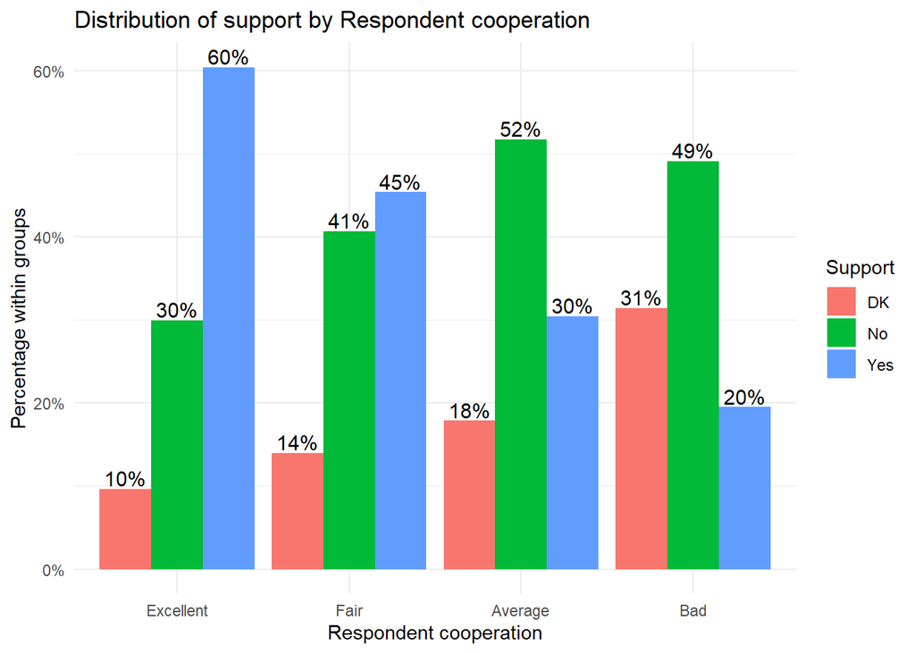

```r
data_summary <- merged_paradata |>
  count(p5, trans_docs, name = "n") |>
  group_by(p5) |>
  mutate(percentage = n / sum(n))

ggplot(data_summary, aes(x = p5, y = percentage, fill = trans_docs)) +
  geom_bar(stat = "identity", position = "dodge") +
  geom_text(aes(label = scales::percent(percentage, accuracy = 1)),
            position = position_dodge(width = 0.9), vjust = -0.2, size = 4) +
  scale_y_continuous(labels = percent_format()) +
  labs(
    title = "Distribution of support by Respondent cooperation",
    x = "Respondent cooperation",
    y = "Percentage within groups",
    fill = "Support"
  ) +
  theme_minimal()
```

```r
# Calcular porcentajes
plot_data <- merged_paradata %>%
  group_by(p5, trans_docs) %>%
  summarise(count = n(), .groups = 'drop') %>%
  mutate(percentage = count / sum(count) * 100)
```

Respondents who engaged better in the survey were more likely to express support.

# Correlation and multicollinearity

Now we want to take a look at the possible multicollinearity of our explanatory variables. For it, we calculate the correlation of our numerical variables. As we have too many variables, we visualize just those with a strong correlation to focus on key dependencies.

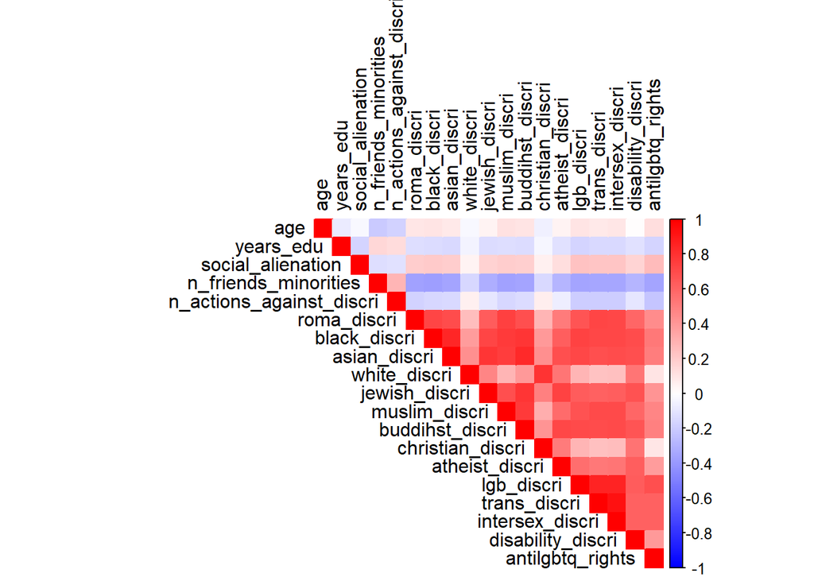

```r
cor_matrix <- cor(data %>%
                    select_if(is.numeric) %>%
                    select(-serialid),
                  use = "complete.obs")

corrplot(cor_matrix, method = "color", type = "upper",
         tl.col = "black",
         col = colorRampPalette(c("blue", "white", "red"))(200))
```

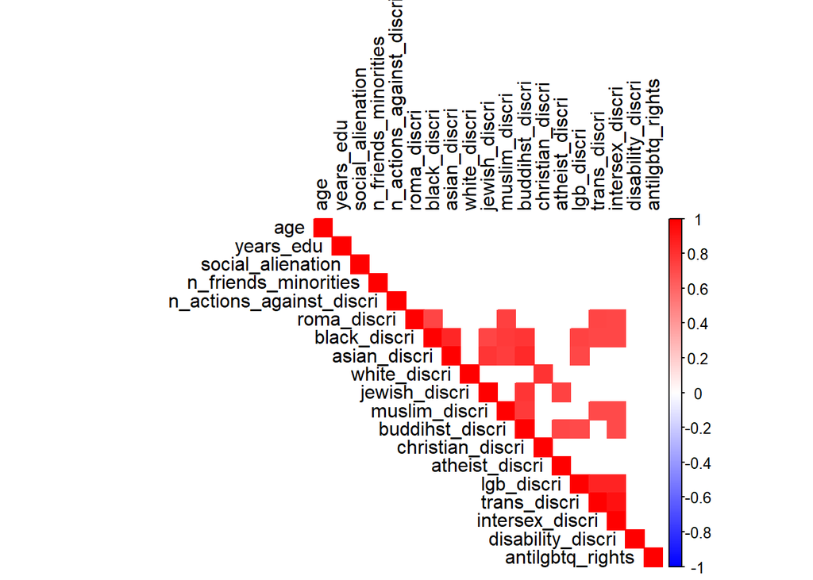

```r
# Create a matrix where only correlations >= 0.7 are maintained
cor_filtered <- ifelse(abs(cor_matrix) >= 0.7, cor_matrix, NA)

# Graph
corrplot(cor_filtered, method = "color", type = "upper",
         tl.col = "black",
         col = colorRampPalette(c("blue", "white", "red"))(200),
         na.label = " ",
         insig = "blank")
```

Most strong correlations are among variables related race, religion or sexual orientation discrimination. Consequently, we are grouping them into 3 new composite variables by averaging related ones, in order to reduce multicollinearity.

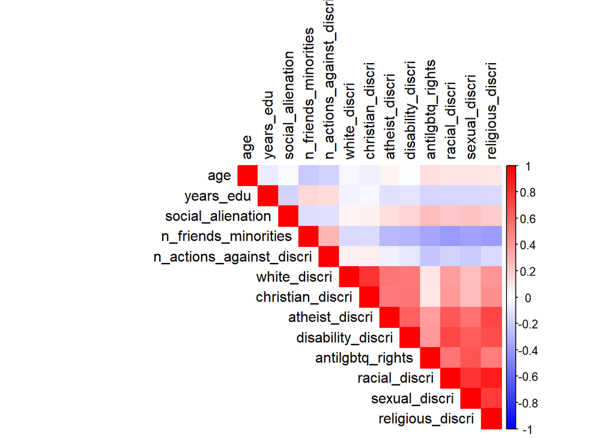

```r
# Creating grouped variables
data <- data %>%
  mutate(
    racial_discri = rowMeans(select(., roma_discri, black_discri, asian_discri), na.rm = TRUE), #no white
    sexual_discri = rowMeans(select(., lgb_discri, trans_discri, intersex_discri), na.rm = TRUE),
    religious_discri = rowMeans(select(., jewish_discri, muslim_discri, buddihst_discri), na.rm = TRUE)
  )

# Removing original variables to avoid redundancy
data <- data |>
  select(-c(roma_discri, black_discri, asian_discri, lgb_discri, trans_discri, intersex_discri, jewish_discri, muslim_discri, buddihst_discri))


# Graphical representation
cor_matrix <- cor(data %>%
                    select_if(is.numeric) %>%
                    select(-serialid),
                  use = "complete.obs")


corrplot(cor_matrix, method = "color", type = "upper",
         tl.col = "black",
         col = colorRampPalette(c("blue", "white", "red"))(200))
```

We realize our new variables are still highly correlated between them. For reducing the dimensionality of the dataset even more while preserving information we create one single variable for general minority discrimination.

```r
# Creating grouped variable
data <- data %>%
  mutate(
    minority_discri = rowMeans(select(., racial_discri, sexual_discri, religious_discri, disability_discri), na.rm = TRUE))
```

```r
summary(data$white_discri)
```

```
##    Min. 1st Qu.  Median    Mean 3rd Qu.    Max.    NA's
##   1.000   1.000   1.000   1.785   2.000  10.000     403
```

```r
summary(data$atheist_discri)
```

```
##    Min. 1st Qu.  Median    Mean 3rd Qu.    Max.    NA's
##   1.000   1.000   1.500   2.802   4.000  10.000     517
```

```r
summary(data$christian_discri)
```

```
##    Min. 1st Qu.  Median    Mean 3rd Qu.    Max.    NA's
##   1.000   1.000   1.000   1.904   2.000  10.000     414
```

```r
data <- data |>
  select(-c(white_discri, atheist_discri, christian_discri, racial_discri, sexual_discri, religious_discri, disability_discri))
```

Final check of the correlation matrix to confirm that multicollinearity has been reduced.

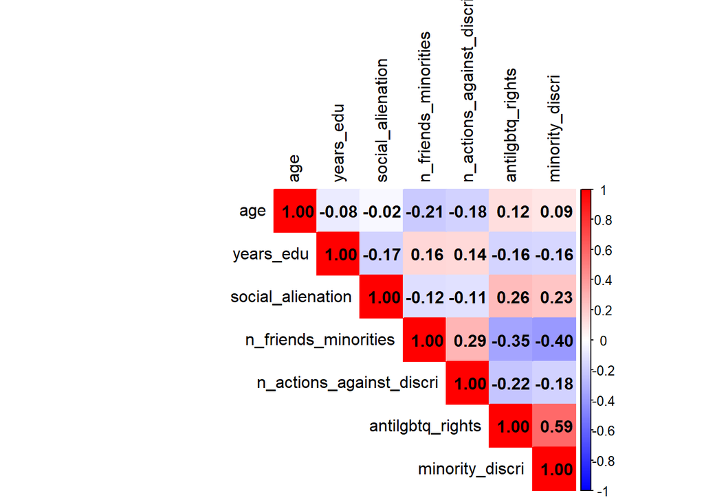

```r
cor_matrix <- cor(data %>%
                    select_if(is.numeric) %>%
                    select(-serialid),
                  use = "complete.obs")


corrplot(cor_matrix, method = "color", type = "upper",
         addCoef.col = "black", tl.col = "black",
         col = colorRampPalette(c("blue", "white", "red"))(200))
```

# Class imbalance

```r
prop.table(table(data$trans_docs, useNA = "ifany"))
```

```
##
##       Yes        No      <NA>
## 0.5271157 0.3533421 0.1195422
```

```r
prop.table(table(data$trans_docs, useNA = "no"))
```

```
##
##       Yes        No
## 0.5986837 0.4013163
```

Our target variable has a 60/40 distribution so we are not worried about class imbalance.

Less represented classes in other variables have already been aggregated if deemed necessary.

# Analysis of missing values

Here we analyse the NA reponses to our target variable. This is a sort of robustness check to understand our data and learn if there are patterns in NA response that we should be worried about e.g. if there are specific demographics of people are less likely to respond.

Overall the analysis below shows that non response is similar to the descriptive data and aligned with some groups reported “No” to supporting trans_docs in c19. So we’re more at risk of underreporting “no” votes in this survey due to non-response. The correlation is low though so it’s not a major concern.

## Who is more likely to not respond to our target?

There are 3,280 NA responses to the target variable. To try understand if the missing values are at random, we will test the correlation between NA response and Use the DK (don’t know) for our target variable.

In the descriptive analysis above, we have already seen in raw terms that NA responses were more frequent from some groups e.g.

- women,
- older people,
- people who also responded NA for political ideology,
- People who do not have trans friends and those who refused to respond to the friendship question had higher NA responses to the target variable.
- People with lower survey cooperation
- By country, we already understand from the challenge description that the NA responses vary. This is a significant disparity.

Create a binary variable for the DK

```r
cntry_name <- codelist |> select(iso2c, country_name = country.name.en)
dk_target <- data |>
  mutate(target_NA = ifelse(is.na(trans_docs), 1, 0)) |>
  left_join(cntry_name, by = join_by(country == iso2c)) |>
  dplyr::select(-trans_docs, -serialid, -country)

table(dk_target$target_NA)
```

```
##
##     0     1
## 24158  3280
```

Confirm DK rates by country. They vary from 1.4% in Belgium to 28.5% in Bulgaria. Overall, the average is 11.95%.

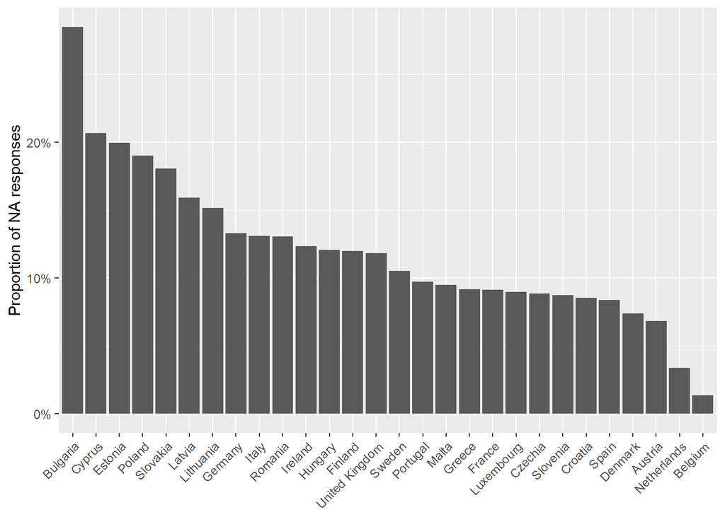

```r
dk_target |>
  group_by(country_name) |>
  summarise(count_na = sum(target_NA),
            num_resp = length(country_name),
            pct_na = count_na/num_resp*100) |>
  ggplot(aes(x=reorder(country_name, -pct_na), y = pct_na))+
  geom_col()+
  theme(axis.text.x = element_text(angle = 45, hjust = 1),
        axis.title.x = element_blank()) +
  scale_y_continuous(labels = scales::percent_format(scale = 1)) +
  labs(y = "Proportion of NA responses")
```

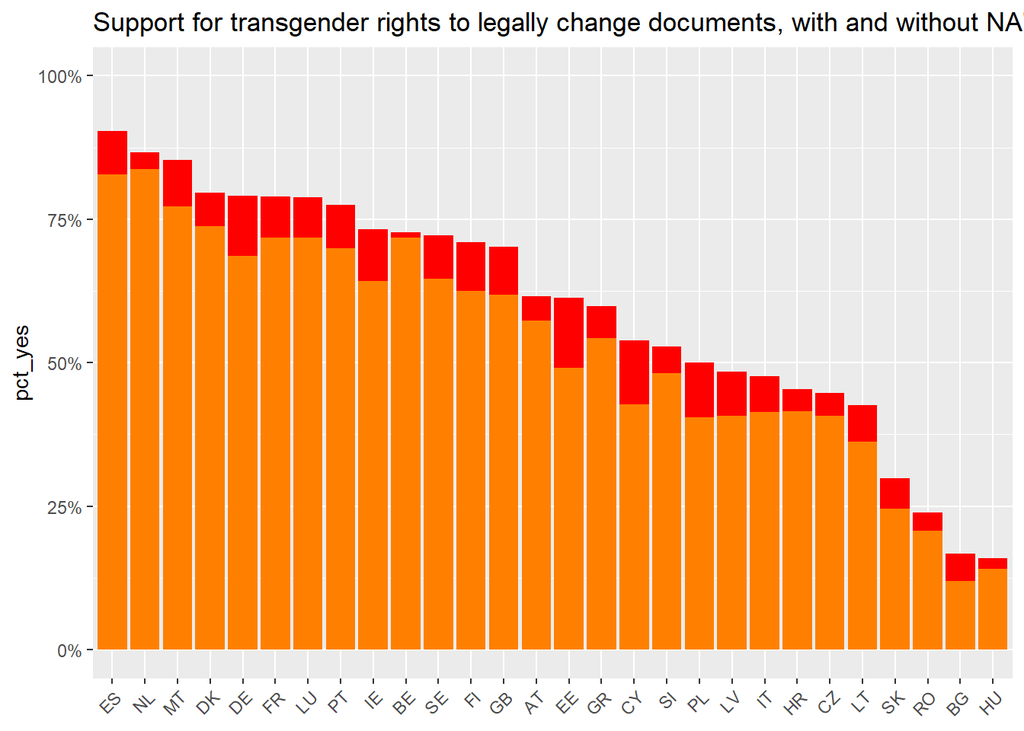

```r
data |>
  group_by(country) |>
  summarise(yes_count = sum(trans_docs == "Yes", na.rm=TRUE),
            num_resp = sum(!is.na(trans_docs)),
            num_na = sum(is.na(trans_docs)),
            pct_yes_withna = yes_count / length(country)*100,
            pct_yes = yes_count/num_resp*100)|>
  ggplot(aes(x = reorder(country, -pct_yes))) +
  geom_col(aes(y = pct_yes), fill = "red") + # First bar (pct_yes)
  geom_col(aes(y = pct_yes_withna), fill = "yellow", alpha = 0.5) + # Second bar (pct_yes_withna)
  theme(axis.text.x = element_text(angle = 45, hjust = 1),
        axis.title.x = element_blank()) +
  scale_y_continuous(labels = scales::percent_format(scale = 1),
                     limits = c(0,100)) +
  labs(title ="Support for transgender rights to legally change documents, with and without NA's")
```

### Check correlation with DK of target

Run model to test what is correlated with DK response, use Cramers V for association between the factor variables and correlation for the numeric variables in the cleaned data.

1. Model the data for DK responses against the factor variables.

```r
factor_subset <- dk_target %>%
  dplyr::select(target_NA, where(is.factor)) |>
  mutate(target_NA = factor(target_NA))

# Run cramers V for factors

target_var <- "target_NA"
factor_variables <- names(factor_subset)
factor_variables <- factor_variables[factor_variables != target_var]

cramers_v_results <- list()

for (variable in factor_variables) {
    contingency_table <- table(factor_subset[[target_var]],
                               factor_subset[[variable]])
    cramers_v <- CramerV(contingency_table)
    cramers_v_results[[variable]] <- cramers_v
}

# Create a Tibble for Results
cat_results <- tibble(variable = names(cramers_v_results),
       cramers_v = unlist(cramers_v_results)) |>
  arrange(desc(cramers_v))
cat_results
```

```
## # A tibble: 22 × 2
##    variable       cramers_v
##    <chr>              <dbl>
##  1 internet_use      0.136
##  2 social_class      0.0975
##  3 occupation        0.0852
##  4 marital_status    0.0831
##  5 gender_docs       0.0820
##  6 religion          0.0763
##  7 phone_access      0.0711
##  8 life_sat          0.0642
##  9 polintr           0.0621
## 10 friends_trans     0.0581
## # ℹ 12 more rows
```

This shows all of the factors have quite low association with the NA responses. The highest being internet use. This is a good sign that the missing values are random.

2. Look at the numeric variables and test correlations:

```r
numeric_subset <- dk_target %>%
  dplyr::select(target_NA, where(is.numeric))

target_var <- "target_NA"
numeric_variables <- names(numeric_subset)[names(numeric_subset) != target_var]

cor_results <- list()

for (variable in numeric_variables) {
    correlation <- cor(numeric_subset$target_NA,
                       numeric_subset[[variable]],
                       use = "pairwise.complete.obs")
    cor_results[[variable]] <- correlation
}

# Create a Tibble for Results
cor_results <- tibble(variable = names(cor_results),
       cor = unlist(cor_results)) |>
  arrange(cor)
cor_results
```

```
## # A tibble: 7 × 2
##   variable                     cor
##   <chr>                      <dbl>
## 1 n_actions_against_discri -0.0988
## 2 n_friends_minorities     -0.0965
## 3 years_edu                -0.0544
## 4 social_alienation         0.0566
## 5 minority_discri           0.0635
## 6 age                       0.0982
## 7 antilgbtq_rights          0.108
```

Again, this is not too much cause for concern. We only have around 10% correlations, positive and negative with the target variable.

### Modelling relationship with key variables and non-response

```r
cor_results |> filter(cor > 0.09 | cor < -0.9) |> pull(variable)
```

```
## [1] "age"              "antilgbtq_rights"
```

```r
cat_results |> filter(cramers_v >0.1) |> pull(variable)
```

```
## [1] "internet_use"
```

Now model with those variables to see if they are significant in explaining the DK values. Gender will also be included as a key variable.

We run a stepwise AIC on these most correlated variables and then use the best model to test the overall model fit.

```r
# first, run stepwise to determine most important
# run base model
dk_fit_null <- glm(target_NA ~ 1,
              data = dk_target,
              family = "binomial")
# run full fit model of most correlated vars with country (also age^2 for good practice)
dk_fit <- glm(target_NA ~ gender + age + I(age*age) + antilgbtq_rights + internet_use + social_class + country_name,
              data = dk_target,
              family = "binomial")

# use stepwise to select best mode l
aic_1 <- MASS::stepAIC(dk_fit, scope = list(upper = dk_fit,
                             lower = dk_fit_null),
        direction = "both", k = 2, trace=0) # forward based on AIC

# filter vars significant at 5% and calculate exponential
broom::tidy(aic_1) |>
  filter(p.value<0.05) |>
  mutate(oddsratio = exp(estimate)) |>
  select(term, oddsratio, p.value)
```

```
## # A tibble: 29 × 3
##    term                                          oddsratio  p.value
##    <chr>                                             <dbl>    <dbl>
##  1 (Intercept)                                      0.0500 8.78e-40
##  2 genderWoman                                      1.20   2.01e- 5
##  3 I(age * age)                                     1.00   4.77e- 4
##  4 antilgbtq_rights                                 1.13   9.69e- 7
##  5 internet_useTwo or three times a week            1.21   2.72e- 2
##  6 internet_useTwo or three times a month           0.307  4.97e- 3
##  7 internet_useNever/No access                      1.28   2.49e- 4
##  8 internet_useNo Internet access at all            1.57   4.62e- 4
##  9 social_classThe lower middle class of society    0.766  4.62e- 5
## 10 social_classThe middle class of society          0.713  4.09e-11
## # ℹ 19 more rows
```

The best model is the one without age but includes age^2. So we run the full model to keep the lower level variables included.

~~~~~~~~~ SHOULD WE DELETE THIS SECTION ON UNDERSAMPLING/CLASS IMBALANCE~~~~

Below is an option using undersampling which is probably more legit too. maybe good to include if we aren’t doing in other sections.

```r
# split to test and training
na_model <- glm(target_NA ~ .,
                      data = dk_target,
                      family = "binomial")
summary(na_model)
```

```
##
## Call:
## glm(formula = target_NA ~ ., family = "binomial", data = dk_target)
##
## Coefficients:
##                                                       Estimate Std. Error
## (Intercept)                                          -5.096435   0.505490
## age                                                   0.012178   0.004217
## genderWoman                                           0.164789   0.082464
## years_edu                                            -0.005912   0.007160
## communitySmall or middle sized town                   0.060070   0.095266
## communityLarge town                                  -0.083705   0.106848
## marital_statusSingle living with partner (5-8 in d7) -0.229059   0.153178
## marital_statusSingle (9-10 in d7)                    -0.151896   0.148656
## marital_statusDivorced or separated (11-12 in d7)     0.289686   0.129040
## marital_statusWidow (13-14 in d7)                     0.216811   0.125780
## occupationManagers (10 to 12 in d15a)                 0.074469   0.188675
## occupationOther white collars (13 or 14 in d15a)     -0.002162   0.186434
## occupationManual workers (15 to 18 in d15a)          -0.087856   0.174101
## occupationHouse persons (1 in d15a)                  -0.244480   0.263347
## occupationUnemployed (3 in d15a)                      0.032945   0.250771
## occupationRetired (4 in d15a)                        -0.152771   0.176731
## occupationStudents (2 in d15a)                       -0.516985   0.364050
## social_classThe lower middle class of society        -0.191067   0.127529
## social_classThe middle class of society              -0.102517   0.102911
## social_classThe upper middle class of society        -0.048871   0.182548
## social_classThe higher class of society               0.028047   0.527417
## religionOrthodox Christian                           -0.272443   0.208576
## religionProtestant                                    0.161109   0.154425
## religionOther Christian                              -0.132124   0.206172
## religionOther                                        -0.791153   0.279671
## religionMuslim                                        0.691685   0.325376
## religionNon-believers                                -0.020914   0.130285
## nonEU_national1                                      -0.370848   1.018180
## phone_accessLandline only                            -0.110733   0.229728
## phone_accessLandline & mobile                         0.039715   0.100780
## phone_accessNo telephone                             -0.500657   0.355297
## bill_issuesFrom time to time                          0.232590   0.188589
## bill_issuesAlmost never/never                         0.457448   0.188085
## internet_useTwo or three times a week                 0.184435   0.156891
```

[output cut: 141 more lines]

```
## country_nameSlovenia                                   0.447  0.65483
## country_nameSpain                                     -0.995  0.31985
## country_nameSweden                                     2.565  0.01032 *
## country_nameUnited Kingdom                             1.656  0.09775 .
## ---
## Signif. codes:  0 '***' 0.001 '**' 0.01 '*' 0.05 '.' 0.1 ' ' 1
##
## (Dispersion parameter for binomial family taken to be 1)
##
##     Null deviance: 6149.9  on 18337  degrees of freedom
## Residual deviance: 5702.8  on 18249  degrees of freedom
##   (9100 observations deleted due to missingness)
## AIC: 5880.8
##
## Number of Fisher Scoring iterations: 7
```

```r
broom::tidy(na_model)
```

```
## # A tibble: 89 × 5
##    term                                    estimate std.error statistic  p.value
##    <chr>                                      <dbl>     <dbl>     <dbl>    <dbl>
##  1 (Intercept)                             -5.10      0.505     -10.1   6.62e-24
##  2 age                                      0.0122    0.00422     2.89  3.88e- 3
##  3 genderWoman                              0.165     0.0825      2.00  4.57e- 2
##  4 years_edu                               -0.00591   0.00716    -0.826 4.09e- 1
##  5 communitySmall or middle sized town      0.0601    0.0953      0.631 5.28e- 1
##  6 communityLarge town                     -0.0837    0.107      -0.783 4.33e- 1
##  7 marital_statusSingle living with partn… -0.229     0.153      -1.50  1.35e- 1
##  8 marital_statusSingle (9-10 in d7)       -0.152     0.149      -1.02  3.07e- 1
##  9 marital_statusDivorced or separated (1…  0.290     0.129       2.24  2.48e- 2
## 10 marital_statusWidow (13-14 in d7)        0.217     0.126       1.72  8.48e- 2
## # ℹ 79 more rows
```

```r
exp(coefficients(na_model))
```

```
##                                          (Intercept)
##                                          0.006118521
##                                                  age
##                                          1.012252085
##                                          genderWoman
##                                          1.179144394
##                                            years_edu
##                                          0.994105573
##                  communitySmall or middle sized town
##                                          1.061910918
##                                  communityLarge town
##                                          0.919702513
## marital_statusSingle living with partner (5-8 in d7)
##                                          0.795281376
##                    marital_statusSingle (9-10 in d7)
##                                          0.859077470
##    marital_statusDivorced or separated (11-12 in d7)
##                                          1.336008000
##                    marital_statusWidow (13-14 in d7)
##                                          1.242109894
##                occupationManagers (10 to 12 in d15a)
##                                          1.077311509
##     occupationOther white collars (13 or 14 in d15a)
##                                          0.997840105
##          occupationManual workers (15 to 18 in d15a)
##                                          0.915892418
##                  occupationHouse persons (1 in d15a)
##                                          0.783111899
##                     occupationUnemployed (3 in d15a)
##                                          1.033494121
##                        occupationRetired (4 in d15a)
##                                          0.858326624
##                       occupationStudents (2 in d15a)
##                                          0.596316021
##        social_classThe lower middle class of society
##                                          0.826076903
##              social_classThe middle class of society
##                                          0.902562665
##        social_classThe upper middle class of society
##                                          0.952304428
```

[output cut: 123 more lines]

```
##                                          1.651040115
##                                 country_namePortugal
##                                          0.712123337
##                                  country_nameRomania
##                                          0.976758747
##                                 country_nameSlovakia
##                                          1.283136036
##                                 country_nameSlovenia
##                                          1.163574636
##                                    country_nameSpain
##                                          0.677063226
##                                   country_nameSweden
##                                          2.274838960
##                           country_nameUnited Kingdom
##                                          1.724509350
```

Approach to test relationship to DK with splitting and undersampling:

```r
# create new dataset with just vars we want, including age^2
dk_target2 <- dk_target |>
  select(target_NA, age, antilgbtq_rights, internet_use, social_class, country_name) |>
  mutate(age_sq = age*age, .after = age)

# to deal with some class imbalance, undersample from the majority group (NA = 0)
set.seed(123)
# Generate an index
index <- createDataPartition(dk_target2$target_NA, p = 0.7, list = FALSE, times = 1)

# Subset the dataframe
train <- dk_target2[index, ]
test <- dk_target2[-index, ]
# check splits
prop.table(table(train$target_NA))
```

```
##
##         0         1
## 0.8787421 0.1212579
```

```r
prop.table(table(test$target_NA))
```

```
##
##         0         1
## 0.8844612 0.1155388
```

Now undersample the majority

```r
set.seed(123)
under <- ovun.sample(target_NA~.,
                     data=train,
                     method = "under",
                     N = 4000)$data
    # limit the sample to 4000 obs as we have ~2300 for target minority class.

table(under$target_NA)
```

```
##
##    0    1
## 2112 1888
```

```r
#run the rf model
rfunder <- randomForest(target_NA~., data=under)
rfunder
```

```
##
## Call:
##  randomForest(formula = target_NA ~ ., data = under)
##                Type of random forest: regression
##                      Number of trees: 500
## No. of variables tried at each split: 2
##
##           Mean of squared residuals: 0.2389922
##                     % Var explained: 4.1
```

We see that only around 5% of the variance is explained.

~~~ REMOVE TO HERE IF WE DON’T WANT THE ABOVE

### Testing the NA values against paradata

Here we extend the model to see if paradata is related to changed non-response.

```r
para <- paradata |>
  bind_cols(trans_docs = data$trans_docs,
            age = data$age,
            gender = data$gender,
            country = data$country) |>
  mutate(target_NA = ifelse(is.na(trans_docs), 1, 0)) |>
  select(-serialid, -trans_docs)

summary(para$target_NA)
```

```
##    Min. 1st Qu.  Median    Mean 3rd Qu.    Max.
##  0.0000  0.0000  0.0000  0.1195  0.0000  1.0000
```

```r
str(para)
```

```
## tibble [27,438 × 9] (S3: tbl_df/tbl/data.frame)
##  $ p2       : Factor w/ 6 levels "Before 8 h","8 - 12 h",..: 4 4 3 4 2 4 5 2 4 4 ...
##   ..- attr(*, "label")= chr "TIME OF INTERVIEW"
##  $ p3       : Factor w/ 246 levels "2 minutes","3",..: 44 39 37 30 30 25 26 33 39 39 ...
##   ..- attr(*, "label")= chr "DURATION OF INTERVIEW"
##  $ p3r      : Factor w/ 7 levels "Up to 14 minutes",..: 4 3 3 3 3 2 2 3 3 3 ...
##   ..- attr(*, "label")= chr "DURATION OF INTERVIEW (RECODED)"
##  $ p4       : Factor w/ 5 levels "Two (interviewer and respondent)",..: 1 1 1 1 1 1 1 1 1 1 ...
##   ..- attr(*, "label")= chr "N OF PERSONS PRESENT DURING INTERVIEW"
##  $ p5       : Factor w/ 5 levels "Excellent","Fair",..: 1 1 1 1 1 1 1 1 1 1 ...
##   ..- attr(*, "label")= chr "RESPONDENT COOPERATION"
##  $ age      : num [1:27438] 51 62 38 29 63 41 48 88 44 45 ...
##  $ gender   : Factor w/ 2 levels "Man","Woman": 1 2 2 1 2 2 1 1 2 2 ...
##  $ country  : chr [1:27438] "BE" "BE" "BE" "BE" ...
##  $ target_NA: num [1:27438] 0 0 0 0 0 0 0 0 0 0 ...
```

First, again test correlation. We use Cramers V since we only have factors:

```r
target_var <- "target_NA"
para_vars <- names(para)[names(para) != target_var]

cramers_v_results <- list()

for (variable in para_vars) {
    contingency_table <- table(para[[target_var]],
                               para[[variable]])
    contingency_table_no_dk <- contingency_table[, colnames(contingency_table) != "DK"]
    cramers_v <- CramerV(contingency_table_no_dk)
    # include this for no DK as it is all zero which creates errors
    cramers_v_results[[variable]] <- cramers_v
}


# Create a Tibble for Results
tibble(variable = names(cramers_v_results),
       cramers_v = unlist(cramers_v_results)) |>
  arrange(desc(cramers_v))
```

```
## # A tibble: 8 × 2
##   variable cramers_v
##   <chr>        <dbl>
## 1 country     0.168
## 2 age         0.123
## 3 p5          0.106
## 4 p3          0.0916
## 5 gender      0.0292
## 6 p4          0.0165
## 7 p2          0.0116
## 8 p3r         0.0113
```

Again, we see low correlation with the paradata and cramers V.

Second, we run another logistic model with just Paradata included.

```r
na_para_model <- glm(target_NA ~ p2 + p3r + p4 + p5 + age + I(age*age) + gender + factor(country),
                     data = para,
                     family=binomial(link = "logit"))

broom::tidy(na_para_model) |>
  filter(p.value<0.05) |>
  mutate(oddsratio = exp(estimate)) |>
  select(term, oddsratio, p.value)
```

```
## # A tibble: 25 × 3
##    term              oddsratio  p.value
##    <chr>                 <dbl>    <dbl>
##  1 (Intercept)          0.0439 4.65e-12
##  2 p4Four               0.694  4.20e- 2
##  3 p5Fair               1.42   2.05e-15
##  4 p5Average            1.74   8.91e-18
##  5 p5Bad                3.49   2.14e-22
##  6 age                  0.983  2.85e- 3
##  7 I(age * age)         1.00   3.43e- 9
##  8 genderWoman          1.14   1.07e- 3
##  9 factor(country)BE    0.179  6.77e- 9
## 10 factor(country)BG    5.30   2.16e-31
## # ℹ 15 more rows
```

We see that when controlling for age, gender and country, the survey cooperation variable is significant.

Overall, the correlations with our target variables are low which means we don’t have a major concern. Some are interesting e.g. interview cooperation. The worse the cooperation, the more likely to not respond to the question. This could be underreporting No votes, because as we saw in the descriptive analysis, the worse the cooperation, the higher the No vote for supporting trans_docs. There could also be some reverse causality, as not responding leads to a worse cooperation score. But the odds ratios here are very high.

# Imputing missing data

As we have different types of variables we decide to go with the default methods. Selecting the best method for each type of variable would be too computationally intensive

```r
# Excluding target variable and other useless variables
imputation_data <- data |>
  select(-c(serialid, country, trans_docs))

# Running it with the default methods
# We can change m in case we decide to use pool later instead of just completing 1 df)
imputed_data <- mice(imputation_data, m = 1, seed=1234)
# By default: numerical variables -> pmm, binary factors -> logreg, > 2 levels factors -> polyreg
imputed_data$method
```

```
##                      age                   gender                years_edu
##                       ""                       ""                    "pmm"
##                community           marital_status               occupation
##                "polyreg"                "polyreg"                       ""
##             social_class                 religion           nonEU_national
##                "polyreg"                "polyreg"                       ""
##             phone_access              bill_issues             internet_use
##                       ""                "polyreg"                       ""
##                 life_sat                  polintr               left_right
##                "polyreg"                       ""                "polyreg"
##        social_alienation          ethnic_minority       skincolor_minority
##                    "pmm"                       ""                       ""
##       religious_minority            roma_minority          sexual_minority
##                       ""                       ""                       ""
##      disability_minority           suffered_discr              gender_docs
##                       ""                       ""                 "logreg"
##            friends_trans     n_friends_minorities n_actions_against_discri
##                "polyreg"                       ""                       ""
##         antilgbtq_rights          minority_discri
##                    "pmm"                    "pmm"
```

```r
final_data <- complete(imputed_data)

colSums(is.na(imputation_data))
```

```
##                      age                   gender                years_edu
##                        0                        0                      387
##                community           marital_status               occupation
##                       14                      175                        0
##             social_class                 religion           nonEU_national
##                     1021                      483                        0
##             phone_access              bill_issues             internet_use
##                        0                      379                        0
##                 life_sat                  polintr               left_right
##                      102                        0                     4689
##        social_alienation          ethnic_minority       skincolor_minority
##                     1000                        0                        0
##       religious_minority            roma_minority          sexual_minority
##                        0                        0                        0
##      disability_minority           suffered_discr              gender_docs
##                        0                        0                     3187
##            friends_trans     n_friends_minorities n_actions_against_discri
##                      968                        0                        0
##         antilgbtq_rights          minority_discri
##                      791                      355
```

```r
colSums(is.na(final_data))
```

```
##                      age                   gender                years_edu
##                        0                        0                        0
##                community           marital_status               occupation
##                        0                        0                        0
##             social_class                 religion           nonEU_national
##                        0                        0                        0
##             phone_access              bill_issues             internet_use
##                        0                        0                        0
##                 life_sat                  polintr               left_right
##                        0                        0                        0
##        social_alienation          ethnic_minority       skincolor_minority
##                        0                        0                        0
##       religious_minority            roma_minority          sexual_minority
##                        0                        0                        0
##      disability_minority           suffered_discr              gender_docs
##                        0                        0                        0
##            friends_trans     n_friends_minorities n_actions_against_discri
##                        0                        0                        0
##         antilgbtq_rights          minority_discri
##                        0                        0
```

```r
final_data <- final_data |>
  cbind(data$trans_docs) |>
  cbind(data$country) |>
  rename("trans_docs" = "data$trans_docs",
         "country" = "data$country") |>
  relocate(country, .before = everything())
```

# Joining together all our data

`country_level_data` stores all our data defined at the country level.

`final_data` stores all our data (after imputation) for individual level variables.

```r
complete_df <- final_data |>
  left_join(country_level_data,
            by = join_by(country == iso2c)) |>
  select(-c(country.y, iso3c))
```

# Explanatory model

To be finished…

1. Run logistic with all variables and extract only the significant variables
2. Confirm this is similar to the results we obtain using stepwise regression/lasso regularization
3. Based on 1 & 2 decide which individual level variables to include in the mixed model
4. Build the mixed model (look at the mixed model section for further details on how this needs to be built)

### Simple logistic regression

I am using only individual level data for now

```r
datalr <- final_data |>
  # Dropping NAs (there should be NAs only in our target variable)
  drop_na() |>
  # Selecting only predictor variables
  select(-"country") |>
  # Scale variables
  mutate(across(where(is.numeric), scale))

simple_logistic <- glm(trans_docs ~ ., data = datalr, family = binomial(link = "logit"))

# Save the summary
logistic_summary <- summary(simple_logistic)

# Get all the p-values
p_values <- logistic_summary$coefficients[, 4]

# Extract the significant ones
significant_var <- p_values[p_values < 0.05]
significant_var
```

```
##                                      (Intercept)
##                                     4.640696e-77
##                                              age
##                                     4.765674e-10
##                                      genderWoman
##                                     5.435242e-12
##                marital_statusSingle (9-10 in d7)
##                                     2.418434e-02
## occupationOther white collars (13 or 14 in d15a)
##                                     1.610019e-03
##      occupationManual workers (15 to 18 in d15a)
##                                     3.997818e-02
##                    occupationRetired (4 in d15a)
##                                     1.236632e-04
##                   occupationStudents (2 in d15a)
##                                     9.719876e-03
##                            religionNon-believers
##                                     8.950410e-03
##                    phone_accessLandline & mobile
##                                     2.968026e-12
##                     bill_issuesFrom time to time
##                                     8.359358e-06
##                    bill_issuesAlmost never/never
##                                     4.199023e-03
##            internet_useTwo or three times a week
##                                     4.289740e-08
##                    internet_useAbout once a week
##                                     2.127111e-02
##                      internet_useNever/No access
##                                     1.916582e-07
##                       life_satNot very satisfied
##                                     2.260610e-02
##                     life_satNot at all satisfied
##                                     3.559485e-04
##                          left_right(7 -10) Right
##                                     6.884370e-04
##                                 ethnic_minority1
##                                     3.623336e-02
##                                   roma_minority1
##                                     1.428397e-04
##                                  suffered_discr1
##                                     5.747172e-05
##                                    gender_docsNo
##                                     0.000000e+00
##               friends_transRefusal (SPONTANEOUS)
##                                     2.048302e-05
##                             n_friends_minorities
##                                     6.763512e-14
##                                 antilgbtq_rights
##                                    1.159368e-194
##                                  minority_discri
##                                     1.997081e-24
```

GENERAL COMMENTS AND USEFUL CODE ABOUT LOGISTIC

No support are 1s basically and support are 0s.

From documentation: “the first level denotes failure and all others success”.

```r
levels(datalr$trans_docs)
```

```
## [1] "Yes" "No"
```

```r
# Yes = failure = 0
# No = success = 1
```

```r
# all the coefficients
head(coef(simple_logistic))
```

```
##                         (Intercept)                                 age
##                         -2.69303178                         -0.20879798
##                         genderWoman                           years_edu
##                         -0.26342657                          0.01215087
## communitySmall or middle sized town                 communityLarge town
##                         -0.01810837                          0.04039684
```

```r
# for their interpretation
head(exp(coef(simple_logistic)))
```

```
##                         (Intercept)                                 age
##                          0.06767545                          0.81155917
##                         genderWoman                           years_edu
##                          0.76841404                          1.01222499
## communitySmall or middle sized town                 communityLarge town
##                          0.98205460                          1.04122390
```

`coef(simple_logistic)`: these coefficients represent the change in the log-odds for a one-unit increase in the corresponding independent variable

`exp(coef(simple_logistic))`: the exponential of the slope coefficient (exp(B)) tells us the change of the odds if the independent variable increases by one unit

If the data is scaled:

A coefficient B (from a logistic regression) now reflects the change in the log-odds for a one standard deviation increase in the predictor variable, rather than a one-unit increase in the original scale.

The odds ratio (exp(B)) now tells you how the odds change with a one standard deviation increase in the predictor variable, rather than a one-unit increase.

```r
# AIC of model
simple_logistic$aic
```

```
## [1] 19544.18
```

```r
#predicted probabilities of being a 1 (i.e. a refusal of possibility of trans doc)
predicted_probs <- simple_logistic$fitted.values
# same by running
predicted_probs <- predict(simple_logistic, type = "response")
head(predicted_probs)
```

```
##          1          2          3          4          5          6
## 0.65364799 0.56783545 0.48290107 0.42003376 0.08588506 0.48687469
```

```r
# Turning them to classes using custum threshold
predicted_classes <- ifelse(predicted_probs > 0.5, "No", "Yes")
head(predicted_classes)
```

```
##     1     2     3     4     5     6
##  "No"  "No" "Yes" "Yes" "Yes" "Yes"
```

```r
confusionMatrix(as.factor(datalr$trans_docs), as.factor(predicted_classes))
```

```
## Confusion Matrix and Statistics
##
##           Reference
## Prediction    No   Yes
##        No   7608  2087
##        Yes  2246 12217
##
##                Accuracy : 0.8206
##                  95% CI : (0.8157, 0.8255)
##     No Information Rate : 0.5921
##     P-Value [Acc > NIR] : < 2e-16
##
##                   Kappa : 0.6277
##
##  Mcnemar's Test P-Value : 0.01638
##
##             Sensitivity : 0.7721
##             Specificity : 0.8541
##          Pos Pred Value : 0.7847
##          Neg Pred Value : 0.8447
##              Prevalence : 0.4079
##          Detection Rate : 0.3149
##    Detection Prevalence : 0.4013
##       Balanced Accuracy : 0.8131
##
##        'Positive' Class : No
##
```

```r
roc_obj <- roc(datalr$trans_docs, predicted_probs)
```

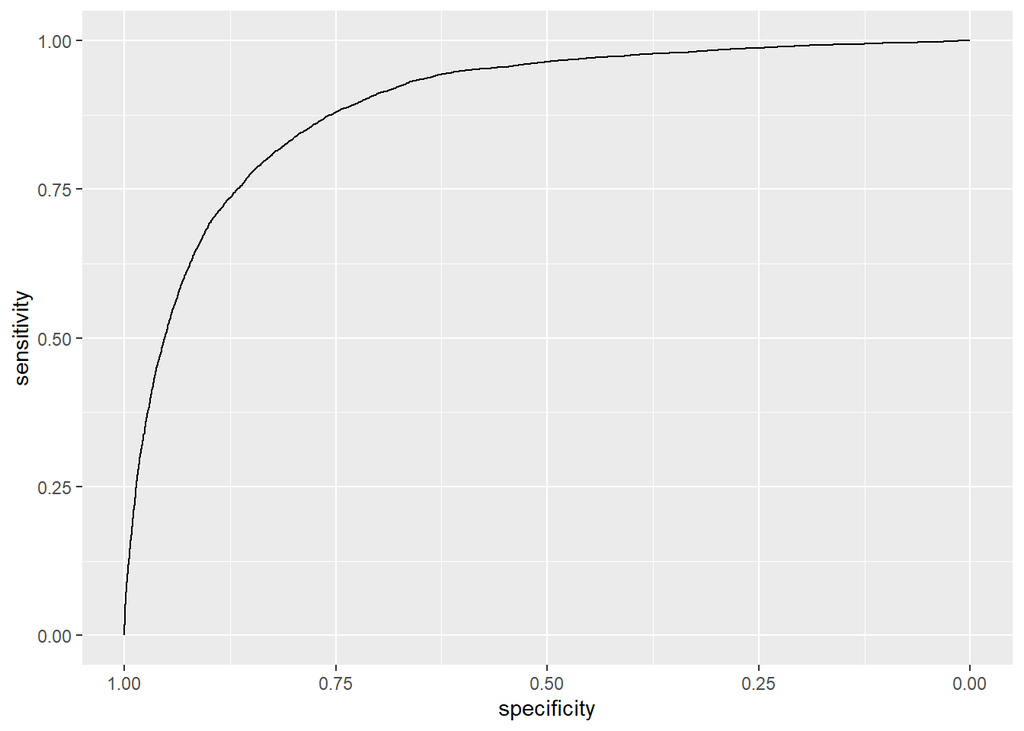

```r
# Terrible graphs, do we have better ones?
pROC::ggroc(roc_obj)
```

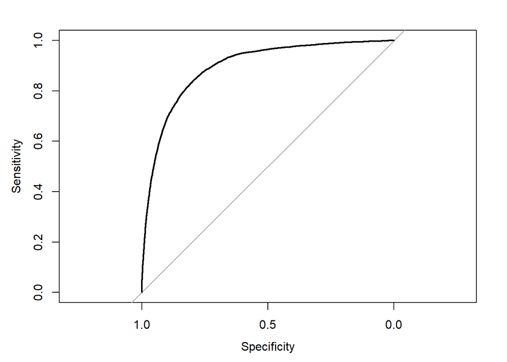

```r
plot(roc_obj)
```

```r
coords(roc_obj, "best")
```

```
##   threshold specificity sensitivity
## 1 0.4062393   0.7938187    0.843115
```

```r
auc(datalr$trans_docs, predicted_probs)
```

```
## Area under the curve: 0.8937
```

## Stepwise regression

Chooses the best model based on the lowest AIC achievable

```r
set.seed(123)
stepAIC <- step(simple_logistic, direction = "both", trace=0)
stepAIC
```

```
##
## Call:  glm(formula = trans_docs ~ age + gender + marital_status + occupation +
##     religion + phone_access + bill_issues + internet_use + life_sat +
##     left_right + ethnic_minority + roma_minority + suffered_discr +
##     gender_docs + friends_trans + n_friends_minorities + n_actions_against_discri +
##     antilgbtq_rights + minority_discri, family = binomial(link = "logit"),
##     data = datalr)
##
## Coefficients:
##                                          (Intercept)
##                                             -2.62467
##                                                  age
##                                             -0.20698
##                                          genderWoman
##                                             -0.26440
## marital_statusSingle living with partner (5-8 in d7)
##                                             -0.04042
##                    marital_statusSingle (9-10 in d7)
##                                             -0.13987
##    marital_statusDivorced or separated (11-12 in d7)
##                                             -0.10517
##                    marital_statusWidow (13-14 in d7)
##                                              0.10979
##                occupationManagers (10 to 12 in d15a)
##                                             -0.01744
##     occupationOther white collars (13 or 14 in d15a)
##                                              0.25937
##          occupationManual workers (15 to 18 in d15a)
##                                              0.14375
##                  occupationHouse persons (1 in d15a)
##                                             -0.05889
##                     occupationUnemployed (3 in d15a)
##                                              0.12589
##                        occupationRetired (4 in d15a)
##                                              0.30665
##                       occupationStudents (2 in d15a)
##                                              0.29364
##                           religionOrthodox Christian
##                                              0.12432
##                                   religionProtestant
```

[output cut: 50 more lines]

```
##                                              0.13252
##                   friends_transRefusal (SPONTANEOUS)
##                                              0.79810
##                                 n_friends_minorities
##                                             -0.15912
##                             n_actions_against_discri
##                                             -0.03980
##                                     antilgbtq_rights
##                                              0.69753
##                                      minority_discri
##                                              0.23593
##
## Degrees of Freedom: 24157 Total (i.e. Null);  24112 Residual
## Null Deviance:       32540
## Residual Deviance: 19430     AIC: 19530
```

## Lasso regularization

```r
# Convert data into a matrix for glmnet
x_lasso <- as.matrix(datalr[, -which(names(datalr) == "trans_docs")])
y_lasso <- as.matrix(datalr$trans_docs)

# Fit the Lasso model (alpha = 1 for Lasso regularization)
lasso_model <- cv.glmnet(x_lasso, y_lasso, family = "binomial", alpha = 1)
# Get all the coefficients
coefficients <- coef(lasso_model, s = "lambda.min")

# Filter for the non-zero ones
non_zero_features <- rownames(coefficients)[which(coefficients != 0)]
non_zero_features
```

```
##  [1] "(Intercept)"              "age"
##  [3] "nonEU_national"           "social_alienation"
##  [5] "ethnic_minority"          "skincolor_minority"
##  [7] "religious_minority"       "roma_minority"
##  [9] "suffered_discr"           "n_friends_minorities"
## [11] "n_actions_against_discri" "antilgbtq_rights"
## [13] "minority_discri"
```

It might not be the best with factors, but it could be useful with numeric

## Mixed model

Random Intercept Model:

Allows the baseline level (intercept) to vary across groups. Assumes the relationship between predictors and outcome (slope) is the same for all groups

In R syntax: y ~ x + (1|group)

Example: Different schools might have different average test scores (random intercepts), but the effect of study hours on test scores is the same across all schools

Random Slope Model:

Allows the effect of a predictor (slope) to vary across groups. Can be used with or without random intercepts.

In R syntax: y ~ x + (0+x|group) for random slope only, or y ~ x + (1+x|group) for both random intercept and slope

Example: The effect of study hours on test scores might be stronger in some schools than others (random slopes)

Random intercept models account for different baselines between groups, while random slope models account for different relationships between predictors and outcomes across groups. When both random intercepts and slopes are included, you’re allowing both the baseline and the effect of predictors to vary by group.

Interactions between group-level (higher-level) variables and individual-level (lower-level) variables in mixed models are called cross-level interactions.

Cross-level interactions are particularly useful in multilevel research because they help you understand how the relationship between an individual-level predictor and the outcome varies as a function of a group-level characteristic.

For example, in educational research: 1) Individual level: student characteristics (study time, prior knowledge). 2) Group level: school or classroom characteristics (class size, teaching method). 3) Cross-level interaction: Does the effect of study time on performance depend on class size?

```r
# Switching to df containing both individual and country level
complete_df <- complete_df |>
  drop_na() # should only be in our target

# Scaling the variables speeds up the running time. However we loose interpretation? maybe the best thing to do is to center them rather than scaling?
scaled_df <- complete_df |>
  mutate(across(where(is.numeric), scale))

glmer_model <- glmer(trans_docs ~ gender:lgbt_policy_index + gender*gender_inequality_index + religion*gdp_pc_ppp + (1 | country), data=scaled_df, family=binomial(link="logit"))

#variable1*variable2 includes both the two variables separetely and their interaction
#variable1:variable2 includes only the interaction
#+ (1|country) country is the grouping variable, means it includes different intercepts for each country

summary(glmer_model) # print in better tables as Marga likes
```

```
## Generalized linear mixed model fit by maximum likelihood (Laplace
##   Approximation) [glmerMod]
##  Family: binomial  ( logit )
## Formula:
## trans_docs ~ gender:lgbt_policy_index + gender * gender_inequality_index +
##     religion * gdp_pc_ppp + (1 | country)
##    Data: scaled_df
##
##      AIC      BIC   logLik deviance df.resid
##  27760.0  27921.9 -13860.0  27720.0    24138
##
## Scaled residuals:
##     Min      1Q  Median      3Q     Max
## -2.7416 -0.6925 -0.4228  0.8840  4.3145
##
## Random effects:
##  Groups  Name        Variance Std.Dev.
##  country (Intercept) 0.2811   0.5302
## Number of obs: 24158, groups:  country, 28
##
## Fixed effects:
##                                       Estimate Std. Error z value Pr(>|z|)
## (Intercept)                           -0.13251    0.10579  -1.253 0.210336
## genderWoman                           -0.45316    0.03005 -15.079  < 2e-16 ***
## gender_inequality_index                0.24291    0.13625   1.783 0.074613 .
## religionOrthodox Christian             0.14645    0.08187   1.789 0.073659 .
## religionProtestant                    -0.13895    0.06647  -2.091 0.036564 *
## religionOther Christian                0.12570    0.07721   1.628 0.103541
## religionOther                         -0.21751    0.07081  -3.072 0.002129 **
## religionMuslim                         0.30067    0.12733   2.361 0.018209 *
## religionNon-believers                 -0.56486    0.04553 -12.407  < 2e-16 ***
## gdp_pc_ppp                            -0.17017    0.10534  -1.615 0.106205
## genderMan:lgbt_policy_index           -0.43635    0.12779  -3.414 0.000639 ***
## genderWoman:lgbt_policy_index         -0.56817    0.12769  -4.450  8.6e-06 ***
## genderWoman:gender_inequality_index    0.03764    0.04140   0.909 0.363264
## religionOrthodox Christian:gdp_pc_ppp  0.16990    0.09189   1.849 0.064484 .
## religionProtestant:gdp_pc_ppp          0.15571    0.08005   1.945 0.051760 .
## religionOther Christian:gdp_pc_ppp     0.04970    0.08077   0.615 0.538373
## religionOther:gdp_pc_ppp               0.10347    0.06959   1.487 0.137032
## religionMuslim:gdp_pc_ppp              0.24140    0.12339   1.956 0.050425 .
## religionNon-believers:gdp_pc_ppp       0.01368    0.04644   0.294 0.768383
## ---
## Signif. codes:  0 '***' 0.001 '**' 0.01 '*' 0.05 '.' 0.1 ' ' 1
```

```
##
## Correlation matrix not shown by default, as p = 19 > 12.
## Use print(x, correlation=TRUE)  or
##     vcov(x)        if you need it
```

```r
# Need to calculate intra class coefficient (proportion of variation explained by the grouping level)
```

The idea is to run interactions between individual level variables and country level variables choosing pair which make sense (ex. does the effect of being female on support for trans docs depend on the gender equality index? –> did this by doing gender*gender_inequality_index)

Let’s use our brain and common sense to choose the best combinations

# Predictive model

Summarize individual data to a country level (ex. percentage of population living in rural areas by country, percentage of people from minority x by country)

Run random forest/gradient boosting/logistic regression with leave-one-out cross validation

## Aggregating individual data to country level

We should be builiding a dataframe with 28 rows (1 per country), but many variables (ex, percentage of christian people by country, percentage of very satisfied with lives people by country, percentage of people that belong to the roma minority etc.; our target variable would become % of people that support trans_docs by country)

Synthesizing the information from the individual respondents into country-level variables? but I don’t know if this is something that models do directly.

My approach was using means for numeric variables:

```r
names(select(data, where(is.numeric)))
```

```
## [1] "serialid"                 "age"
## [3] "years_edu"                "social_alienation"
## [5] "n_friends_minorities"     "n_actions_against_discri"
## [7] "antilgbtq_rights"         "minority_discri"
```

```r
data_num <- data %>%
  group_by(country) %>%
  summarise(across(where(is.numeric), ~mean(. , na.rm = TRUE), .names = "mean_{.col}"))
str(data_num)
```

```
## tibble [28 × 9] (S3: tbl_df/tbl/data.frame)
##  $ country                      : chr [1:28] "AT" "BE" "BG" "CY" ...
##  $ mean_serialid                : num [1:28] 10134 514 15740 16507 17263 ...
##  $ mean_age                     : num [1:28] 46.5 50.2 49.3 51.6 47 ...
##  $ mean_years_edu               : num [1:28] 19.2 19.8 19.4 19.6 19.3 ...
##  $ mean_social_alienation       : num [1:28] 1.93 2.33 2.6 2.98 2.67 ...
##  $ mean_n_friends_minorities    : num [1:28] 2.42 3.32 2.8 3.43 2.31 ...
##  $ mean_n_actions_against_discri: num [1:28] 0.801 0.583 0.109 0.4 0.218 ...
##  $ mean_antilgbtq_rights        : num [1:28] 2.01 1.75 3.09 2.69 2.4 ...
##  $ mean_minority_discri         : num [1:28] 4.19 3.55 5.72 4.56 4.43 ...
```

As well as for dummies:

```r
# searching for factor variables with two levels
dummy_names <- names(data)[sapply(data, is.factor) & sapply(data, function(x) length(levels(x)) == 2)]
dummy_names
```

```
##  [1] "gender"              "nonEU_national"      "ethnic_minority"
##  [4] "skincolor_minority"  "religious_minority"  "roma_minority"
##  [7] "sexual_minority"     "disability_minority" "suffered_discr"
## [10] "trans_docs"          "gender_docs"
```

```r
dummy_levels <- lapply(data[dummy_names], levels)
dummy_levels
```

```
## $gender
## [1] "Man"   "Woman"
##
## $nonEU_national
## [1] "0" "1"
##
## $ethnic_minority
## [1] "0" "1"
##
## $skincolor_minority
## [1] "0" "1"
##
## $religious_minority
## [1] "0" "1"
##
## $roma_minority
## [1] "0" "1"
##
## $sexual_minority
## [1] "0" "1"
##
## $disability_minority
## [1] "0" "1"
##
## $suffered_discr
## [1] "0" "1"
##
## $trans_docs
## [1] "Yes" "No"
##
## $gender_docs
## [1] "Yes" "No"
```

```r
data_dummy <- data %>%
  select(country, all_of(dummy_names)) %>%
  mutate(across(all_of(dummy_names),
                ~ case_when(
                  . %in% c("0", "1") ~ as.numeric(as.character(.)),  # Converts "0"/"1" to 0/1
                  . %in% c("Yes", "No") ~ recode(., "Yes" = 1, "No" = 0),  # Converts "Yes"/"No" to 1/0
                  . %in% c("Man", "Woman") ~ recode(., "Man" = 1, "Woman" = 0),  # Converts "Man"/"Woman" to 1/0
                  TRUE ~ NA_real_  # Assigns NA to other unexpected values
                ),
                .names = "{.col}_num"))
```

I converted factors with 2 levels to numerical 0-1 so we can compute their means.

```r
data_dummy <- data_dummy %>%
  group_by(country) %>%
  summarize(across(ends_with("_num"), \(x) mean(x, na.rm = TRUE)), .groups = "drop")

# substitute the "_num" suffix with a "mean_" prefix so it has the same format as the variables in data_num
data_dummy <- data_dummy %>%
  rename_with(~ paste0("mean_", str_remove(., "_num$")), ends_with("_num"))
str(data_dummy)
```

```
## tibble [28 × 12] (S3: tbl_df/tbl/data.frame)
##  $ country                 : chr [1:28] "AT" "BE" "BG" "CY" ...
##  $ mean_gender             : num [1:28] 0.463 0.499 0.465 0.439 0.438 ...
##  $ mean_nonEU_national     : num [1:28] 0.00389 0.00681 0 0.00596 0 ...
##  $ mean_ethnic_minority    : num [1:28] 0.0497 0.0506 0.0727 0.0179 0.0169 ...
##  $ mean_skincolor_minority : num [1:28] 0.04284 0.05837 0.00775 0.00398 0.01984 ...
##  $ mean_religious_minority : num [1:28] 0.0672 0.073 0.03 0.0219 0.0278 ...
##  $ mean_roma_minority      : num [1:28] 0.03895 0.00584 0.03682 0.00199 0.04266 ...
##  $ mean_sexual_minority    : num [1:28] 0.05258 0.03502 0.00678 0.00398 0.01786 ...
##  $ mean_disability_minority: num [1:28] 0.0526 0.035 0.0116 0.0139 0.0308 ...
##  $ mean_suffered_discr     : num [1:28] 0.28 0.245 0.151 0.115 0.192 ...
##  $ mean_trans_docs         : num [1:28] 0.615 0.728 0.167 0.539 0.447 ...
##  $ mean_gender_docs        : num [1:28] 0.558 0.56 0.0921 0.3879 0.2575 ...
```

Now we can join the two datasets:

```r
data_aggr <- data_num %>%
  left_join(data_dummy, by = "country")
```

The next variables are not numeric nor factor with 2 levels, so they are not included in data_aggr:

```r
names(data)[!sapply(data, is.numeric) &
              !(sapply(data, is.factor) & sapply(data, function(x) length(levels(x)) == 2))]
```

```
##  [1] "country"        "community"      "marital_status" "occupation"
##  [5] "social_class"   "religion"       "phone_access"   "bill_issues"
##  [9] "internet_use"   "life_sat"       "polintr"        "left_right"
## [13] "friends_trans"
```

## Linear regression with LASSO

# Brad’s theory notes

Leaving this section here, it is to be deleted as we incorporate what we need from here into the explanatory model part

#### Running a different logistic model for each country

We now have a table to test some glmer modelling on.

Following this tutorial Marga sent and applying to the test data:

https://raffaelevacca.github.io/Intro-multilevel-with-R/

Testing a nested dataset by country

```r
# Commented the below as we are probably not gonna use it

# nested.cntry <- complete_df %>%
#   group_by(country) %>%
#   nest()
#
# # The column nested.df$data is a list of data frames, one for each country
# class(nested.cntry$data) # type, list
# length(nested.cntry$data) # number of countries
#
# # to unnest()
# nested.cntry %>%
#   filter(country == "AT") %>%
#   dplyr::select(country, data) %>%
#   unnest(cols = c(data))

# # Using the nested data, we now run a model for each country:

# # fit separate lm for each each element of nested.cntry$data)
# lmodels <- nested.cntry %>%
#   # Get all data frames
#   pull(data) %>%
#   # Run glm() on each via map because it's a classification model
#     # model run against all vairables for now.
#   purrr::map(~ glm(trans_docs ~ .,
#                    data= .x,
#                    family = "binomial"))
#
# # show that it's a list and we can call each elements regression output.
# class(lmodels)
# lmodels[4]
```

#### Mixed models

Fixed effects: Things that are the same across the cluster Random effects: Things that change within the cluster

The fixed and random effects could refer to either the intercept or the slope, as these can both vary between groups.

##### LMM equation structure in R

To run a multilevel linear model, we use the lmer() function (“Linear Mixed Effects in R”) from the lme4 package. The syntax is similar to regression. everything to the left of the | indicates the effects that should be random, and the variable to the right of the | is the grouping variable across which the effects should vary

*Null model* This has no slope, but random intercepts. It basically just takes the average. It has no independent (X) variables and is the proper naïve model.

null_model <- lmer(Y ~ (1|cntry), data = ess)

*Random intercept model:* –> Only the intercept differ. The slopes are equal for each group. We assume the same effect of X on Y for each group. Just that the group causes the difference.

random_int_model <- lmer(Y ~ X + (1 | group), data=df)

*Random intercept, random slope model* –> Now we also let the slope vary by group. This means each group basically has it’s own model. It is

random_intslope_model <- lmer(Y ~ X + (X | group), data=df)

For each, Y=target, X = independent vars (can be many)

##### Standard LMM Modelling Strategy

(sourced from slides here: https://favstats.github.io/intro_multilevel/slides/#54) ^ This is a useful resource, it goes through an ESS modelling doc

Approach to multilevel model building based on Hox (2010)

1/ Null Model (Random Intercept only) 2/ Add independent Level 1 variables 3/ Add independent Level 2 variables 4/ Add random slopes 5/ (Cross-level) interactions

Each step, check whether your model is significantly improved compared to the previous one.

##### Basic LMM testing with toy data

First, null model:

```r
# m_null <- glmer(trans_docs ~ (1|country),
#                data = complete_df,
#                family = "binomial",
#                control = glmerControl(optimizer = "bobyqa"),
#                nAGQ = 10)
# summary(m_null)
```

To come back and reinterpret… don’t really know at this stage.

Test flexplot and broom.mixed usage:

```r
# #devtools::install_github("dustinfife/flexplot")
# library(flexplot)
```

Here it has some examples of code and output for saved logistic model fits

```r
# # don't think flexplot will be super useful as we have so many categorical variables
# flexplot::logistic_fit
# flexplot::mixed_logistic
# flexplot::visualize(m_null)
#
# # broom.mixed is used to tidy up the stats outputs into a tibble
# broom.mixed::tidy(m_null) # summary output in tibble
# broom.mixed::glance(m_null) # model performance summary
```

Random effects model

- Including individual level variables only with country:

```r
# n_randeffect <- glmer(trans_docs ~
#                         gender + age + I(age^2) + life_sat + religion + social_class +
#                         (1|country),
#                data = complete_df,
#                family = "binomial",
#                control = glmerControl(optimizer = "bobyqa"),
#                nAGQ = 10)
```

```r
# # check for nearzero variance, if so those could be removed
# nearZeroVar(complete_df, saveMetrics = TRUE)
# # see no issues. So all variables stay.
#
# # will recode the numeric variables I selected, which is only age
# scaled_df <- complete_df |>
#   mutate(across(where(is.numeric), scale))
```

Re check the random effects model with scaled data:

```r
# n_randeffect <- glmer(trans_docs ~
#                         gender + age + I(age^2) + life_sat + (1|country),
#                data = scaled_df,
#                family = "binomial",
#                control = glmerControl(optimizer = "bobyqa"),
#                nAGQ = 10)
#
#
#
# summary(n_randeffect)
```

Can we interpret this…

*Example Random effects models:* m <- glmer(remission ~ IL6 + CRP + CancerStage + LengthofStay + Experience + (1 | DID), data = hdp, family = binomial, control = glmerControl(optimizer = “bobyqa”), nAGQ = 10)

*Example from last year code* glm_model_4 <- glmer(binary_qc19 ~ male + d11 + I(d11^2) + political_ideology + Religion_cat + sd1_7_factor + d60_ordinal + qc15_1_ordinal + prop_gndr_bin + prop_dis_wide + Unemployment + (1 | country_name), data = Data, family = binomial, control = glmerControl(optimizer = “bobyqa”, optCtrl = list(maxfun = 100000)))

*Potentially useful package for visualising and interpreting linear mixed models:* Flexplot -> https://github.com/dustinfife/flexplot Functions to quickly visualise LMM models and compare their performance.

broom.mixed The function broom.mixed::tidy() gives us all model parameters (random and fixed).

*Useful calculations:* - ICC (intra cluster correlation. How alike each of the observations within each group are) - ANOVA for model comparison: anova(null_model, lvl1_preds_model, lvl2_preds_model, rs_preds_model)